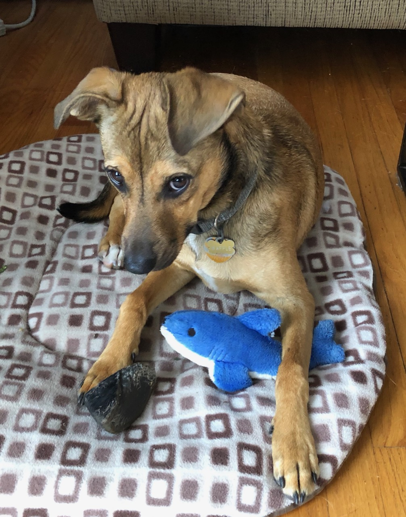

# About me

## My research

Marine ecosystems provide tremendous benefits and services to people, including food provision, economic livelihoods, recreational opportunities, and cultural or spiritual value. But human activity on land and on the ocean, as well as the effects of climate change, is increasingly placing stress on marine ecosystems, threatening delivery of these valuable contributions to human well being. In my research I examine the spatial distribution of impacts of human activity and climate change on marine biodiversity and functional diversity, to inform effective conservation strategies that support a healthy and sustainable marine social-ecological system. I am also keenly interested in the way that perceptions of equity in conservation decisionmaking can influence the sustainability of positive social and ecological outcomes.

I received my Ph.D. from UC Santa Barbara’s Bren School of Environmental Science and Management in 2022, advised by Ben Halpern. I continue to work with the Halpern Lab at the National Center for Ecological Analysis and Synthesis (NCEAS), and teach courses in the Bren School.

Principles of open, reproducible data science are fundamental to my philosophy of practice as a scientist and teacher. [“Our path to better science in less time”](https://www.nature.com/articles/s41559-017-0160) outlines the story of our Ocean Health Index team’s evolution toward best practices of open science, using R, R Studio, and Github to collaborate and communicate our research.

## Other stuff

In a previous life, I taught high school integrated science, physics, and engineering design. As a Senior Fellow of the [Knowles Teacher Initiative](https://knowlesteachers.org/), I continue to work with teachers as a coach and collaborative planner, but I do miss working with my students to help them discover and explore the laws of the universe.

When not saving the world one line of code at a time, I enjoy scuba diving and playing music, but not at the same time. My dog Waffle is the best dog in the world, most of the time. As you can see, he is also concerned about protecting marine biodiversity.